# HDL Cholesterol Triglycerides SPBL Regression

Hajin Jang

1/31/2024

### This analysis uses linear regression models to examine the associations of total cholesterol, triglycerides, and sinking pre-beta lipoprotein with HDL, and evaluates their independent effects, joint contributions, and potential effect modification through multivariable modeling and interaction tests.

```r
# load libraries
library(tidyverse)
library(readxl)
library(car)
library(magrittr)
library(here)
library(multcomp)
```

# Data Management

```r
# read in data using read_xlsx() function
hdl <- read_xlsx("hwdata1.xlsx")
```

## Separate SLR Models

### Part 1) Fitting SLR models

**Separate simple linear regression models for assessing the association of total cholesterol level (cholesterol), total triglyceride level (triglyceride) and sinking pre-beta lipoprotein (spbl) with HDL (HDL) (mg/dL).**

```r
# model with just cholesterol
slr1 <- lm(HDL ~ cholesterol, data = hdl)
summary(slr1)
```

```
##
## Call:
## lm(formula = HDL ~ cholesterol, data = hdl)
##
## Residuals:
##     Min      1Q  Median      3Q     Max
## -18.649  -8.066  -1.267   7.827  28.189
##
## Coefficients:
##             Estimate Std. Error t value Pr(>|t|)
## (Intercept) 52.47018    7.58057   6.922 2.41e-08 ***
## cholesterol -0.01758    0.02763  -0.636    0.528
## ---
## Signif. codes:  0 '***' 0.001 '**' 0.01 '*' 0.05 '.' 0.1 ' ' 1
##
## Residual standard error: 10.69 on 40 degrees of freedom
## Multiple R-squared:  0.01002,    Adjusted R-squared:  -0.01473
## F-statistic: 0.4049 on 1 and 40 DF,  p-value: 0.5282
```

```r
# model with just triglycerides
slr2 <- lm(HDL ~ triglyceride, data = hdl)
summary(slr2)
```

```
##
## Call:
## lm(formula = HDL ~ triglyceride, data = hdl)
##
## Residuals:
##     Min      1Q  Median      3Q     Max
## -21.114  -7.812  -1.188   8.776  27.407
##
## Coefficients:
##               Estimate Std. Error t value Pr(>|t|)
## (Intercept)  46.245193   3.887115  11.897 1.03e-14 ***
## triglyceride  0.009782   0.022690   0.431    0.669
## ---
## Signif. codes:  0 '***' 0.001 '**' 0.01 '*' 0.05 '.' 0.1 ' ' 1
##
## Residual standard error: 10.71 on 40 degrees of freedom
## Multiple R-squared:  0.004625,   Adjusted R-squared:  -0.02026
## F-statistic: 0.1859 on 1 and 40 DF,  p-value: 0.6687
```

```r
# model with just sinking pre-beta
slr3 <- lm(HDL ~ spbl, data = hdl)
summary(slr3)
```

```
##
## Call:
## lm(formula = HDL ~ spbl, data = hdl)
##
## Residuals:
##      Min       1Q   Median       3Q      Max
## -16.7727  -7.7727  -0.7727   5.6943  23.8500
##
## Coefficients:
##             Estimate Std. Error t value Pr(>|t|)
## (Intercept)   43.773      2.099  20.851  < 2e-16 ***
## spbl           8.377      3.042   2.754  0.00882 **
## ---
## Signif. codes:  0 '***' 0.001 '**' 0.01 '*' 0.05 '.' 0.1 ' ' 1
##
## Residual standard error: 9.847 on 40 degrees of freedom
## Multiple R-squared:  0.1594, Adjusted R-squared:  0.1383
## F-statistic: 7.583 on 1 and 40 DF,  p-value: 0.008822
```

Regression models and interpretations:

1. HDL & total cholesterol level
   $$HDL = 52.47 - 0.02cholesterol$$
   The estimated change in HDL with a one-unit increase in total cholesterol level is -0.02.
2. HDL & total triglyceride level
   $$HDL = 46.25 + 0.01triglyceride$$
   The estimated change in HDL with a one-unit increase in total triglyceride level is 0.01.
3. HDL & sinking pre-beta lipoprotein
   $$HDL = 43.77 +
   8.38spbl$$
   The estimated difference in HDL with the presence of sinking pre-beta lipoprotein (spbl) compared to the absence of spbl is 8.38.

### Part 2) Hypothesis testing in SLR models

**Testing whether total cholesterol level, triglyceride level, and sinking pre-beta lipoprotein alone statistically significantly predict y.**

```r
# model with just cholesterol
summary(slr1)
```

```
##
## Call:
## lm(formula = HDL ~ cholesterol, data = hdl)
##
## Residuals:
##     Min      1Q  Median      3Q     Max
## -18.649  -8.066  -1.267   7.827  28.189
##
## Coefficients:
##             Estimate Std. Error t value Pr(>|t|)
## (Intercept) 52.47018    7.58057   6.922 2.41e-08 ***
## cholesterol -0.01758    0.02763  -0.636    0.528
## ---
## Signif. codes:  0 '***' 0.001 '**' 0.01 '*' 0.05 '.' 0.1 ' ' 1
##
## Residual standard error: 10.69 on 40 degrees of freedom
## Multiple R-squared:  0.01002,    Adjusted R-squared:  -0.01473
## F-statistic: 0.4049 on 1 and 40 DF,  p-value: 0.5282
```

```r
# model with just triglycerides
summary(slr2)
```

```
##
## Call:
## lm(formula = HDL ~ triglyceride, data = hdl)
##
## Residuals:
##     Min      1Q  Median      3Q     Max
## -21.114  -7.812  -1.188   8.776  27.407
##
## Coefficients:
##               Estimate Std. Error t value Pr(>|t|)
## (Intercept)  46.245193   3.887115  11.897 1.03e-14 ***
## triglyceride  0.009782   0.022690   0.431    0.669
## ---
## Signif. codes:  0 '***' 0.001 '**' 0.01 '*' 0.05 '.' 0.1 ' ' 1
##
## Residual standard error: 10.71 on 40 degrees of freedom
## Multiple R-squared:  0.004625,   Adjusted R-squared:  -0.02026
## F-statistic: 0.1859 on 1 and 40 DF,  p-value: 0.6687
```

```r
# model with just sinking pre-beta
summary(slr3)
```

```
##
## Call:
## lm(formula = HDL ~ spbl, data = hdl)
##
## Residuals:
##      Min       1Q   Median       3Q      Max
## -16.7727  -7.7727  -0.7727   5.6943  23.8500
##
## Coefficients:
##             Estimate Std. Error t value Pr(>|t|)
## (Intercept)   43.773      2.099  20.851  < 2e-16 ***
## spbl           8.377      3.042   2.754  0.00882 **
## ---
## Signif. codes:  0 '***' 0.001 '**' 0.01 '*' 0.05 '.' 0.1 ' ' 1
##
## Residual standard error: 9.847 on 40 degrees of freedom
## Multiple R-squared:  0.1594, Adjusted R-squared:  0.1383
## F-statistic: 7.583 on 1 and 40 DF,  p-value: 0.008822
```

Interpretation: With an alpha level of 0.05, The pre-beta lipoprotein alone statistically significantly predicted y, while total cholesterol level and triglyceride level did not significantly predict y. The p-value for the slope (as well as the model) was 0.528 (>0.05) for total cholesterol level, 0.669 (>0.05) for total triglyceride level, and 0.009 (<0.05) for pre-beta lipoprotein. According to the R-squared values, total cholesterol explained 1% of HDL, total triglyceride explained 0.5% of HDL, and spbl explained 16% of HDL.

## MLR models

### Part 3) MLR model equation

**Theoretical (population) regression equation used to test whether total cholesterol level, triglyceride level, and sinking pre-beta lipoprotein taken together statistically significantly improve prediction of HDL.**

Model:
$$HDL =
\beta_0 + \beta_1cholesterol + \beta_2triglyceride + \beta_3spbl +
\epsilon$$

Interpretations:

Beta 0: the expected HDL when all covariates are zero (0 total cholesterol, 0 total triglyceride, and absence of spbl).

Beta 1: the expected change in HDL associated with a one-unit increase in total cholesterol, holding total triglyceride and spbl constant.

Beta 2: the expected change in HDL associated with a one-unit increase in total triglyceride, holding total cholesterol and spbl constant.

Beta 3: the expected difference in HDL comparing the presence of spbl to the absence of spbl, holding total cholesterol and triglyceride constant.

### Part 4) Fitting a MLR model and performing a global test

**Fitting the model specified above and testing if total cholesterol level, triglyceride level, and sinking pre-beta lipoprotein taken together statistically significantly improve prediction of HDL.**

```r
# fit MLR model
mlr <- lm(HDL ~ cholesterol + triglyceride + spbl, data = hdl)
summary(mlr)
```

```
##
## Call:
## lm(formula = HDL ~ cholesterol + triglyceride + spbl, data = hdl)
##
## Residuals:
##     Min      1Q  Median      3Q     Max
## -14.140  -7.065  -1.226   6.284  22.616
##
## Coefficients:
##              Estimate Std. Error t value Pr(>|t|)
## (Intercept)  48.86453    7.24985   6.740 5.54e-08 ***
## cholesterol  -0.02731    0.03015  -0.906   0.3707
## triglyceride  0.01504    0.02485   0.605   0.5486
## spbl          8.14831    3.11224   2.618   0.0126 *
## ---
## Signif. codes:  0 '***' 0.001 '**' 0.01 '*' 0.05 '.' 0.1 ' ' 1
##
## Residual standard error: 9.992 on 38 degrees of freedom
## Multiple R-squared:  0.1777, Adjusted R-squared:  0.1128
## F-statistic: 2.737 on 3 and 38 DF,  p-value: 0.05682
```

Interpretation: With an alpha level of 0.05, The pre-beta lipoprotein alone statistically significantly predicted y (p=0.01). Total cholesterol level and triglyceride level did not significantly predict y, with p-values reported as 0.37 and 0.55, respectively. Including all three predictors did not statistically significantly improve the prediction of HDL, with p-value=0.06 for the overall model. The model explained only 18% of HDL and when compared with adjusted R-squared=11%, adding all three predictors did not efficiently improve the model’s predictability.

### Part 5) Variable added test

**Fit a multivariable model and test whether sinking pre-beta (spbl) is associated with HDL after the combined contribution of cholesterol and triglyceride levels is taken into account (i.e., cholesterol and triglycerides are already in the model). Assume no interactions exist. State the appropriate null hypothesis for this test and interpret the results of the test.**

```r
reduced_mlr <- lm(HDL ~ cholesterol + triglyceride, data = hdl)

anova(reduced_mlr, mlr)
```

|  | Res.Df | RSS | Df | Sum of Sq | F | Pr(>F) |
| --- | --- | --- | --- | --- | --- | --- |
| 1 | 39 | 4478.237 | NA | NA | NA | NA |
| 2 | 38 | 3793.872 | 1 | 684.3652 | 6.854707 | 0.0126259 |

Null hypothesis: Beta3 = 0 (slope coefficient for spbl equal to zero)

Test results and interpretation: According to the F test result, we reject the null. The F statistics is statistically significantly large showing that the addition of spbl significantly reduced the residual error (p-value=0.012).

### Part 6) Model for effect modification

**We suppose we are interested in evaluating if the association between cholesterol and HDL and the association between triglycerides and HDL depends on the absence/presence of SPBL.**

Model:
$$HDL =
\beta_0 + \beta_1cholesterol + \beta_2triglyceride + \beta_3spbl +
\beta_4(cholesterol*spbl) + \beta_5(triglyceride*spbl) + \epsilon$$

Interpretation of coefficients:

Beta 0: the expected value of HDL when total cholesterol and triglyceride are 0 and the observation is from the spbl absent (reference) group.

Beta 1: the expected change in HDL for a one-unit change in total cholesterol within the spbl absent (reference) group.

Beta 2: the expected change in HDL for a one-unit change in total triglyceride within the spbl absent (reference) group.

Beta 0 + Beta 3: the expected value of HDL when total cholesterol and triglyceride are 0 and the observation is from the spbl present (non-reference) group.

Beta 1 + Beta 4: the expected change in HDL for a one-unit change in total cholesterol within the spbl present (non-reference) group.

Beta 2 + Beta 5: the expected change in HDL for a one-unit change in total triglyceride within the spbl present (non-reference) group.

### Part 7) Testing for effect modification

**Fitting a multivariable model and testing whether the interactions of cholesterol with SPBL and triglycerides with SPBL are simultaneously equal to zero in a model already containing the three main effects for cholesterol, triglycerides, and SPBL.**

```r
# code to fit model
mlr_int <- lm(HDL ~ cholesterol + triglyceride + spbl + cholesterol*spbl + triglyceride*spbl, data = hdl)

# test
anova(mlr,mlr_int)
```

|  | Res.Df | RSS | Df | Sum of Sq | F | Pr(>F) |
| --- | --- | --- | --- | --- | --- | --- |
| 1 | 38 | 3793.872 | NA | NA | NA | NA |
| 2 | 36 | 3719.052 | 2 | 74.82004 | 0.3621248 | 0.6987025 |

Null hypothesis: Beta 4 = Beta 5 = 0

Interpretation: According to the F test result, we fail to reject the null. The F statistics is not statistically significantly large showing that spbl does not change the way the total cholesterol and triglyceride impact HDL (relationships of total cholesterol and triglyceride with HDL do not depend on level of spbl) (p-value=0.6987).

### Part 8) Checking for confounding

**For sinking pre-beta lipoprotein (spbl), we compare the coefficient for spbl in the full model (in part 4) to the simple model in parts 1 and 2.**

```r
# code to check for confounding
# full model (adjusted model)
summary(mlr)
```

```
##
## Call:
## lm(formula = HDL ~ cholesterol + triglyceride + spbl, data = hdl)
##
## Residuals:
##     Min      1Q  Median      3Q     Max
## -14.140  -7.065  -1.226   6.284  22.616
##
## Coefficients:
##              Estimate Std. Error t value Pr(>|t|)
## (Intercept)  48.86453    7.24985   6.740 5.54e-08 ***
## cholesterol  -0.02731    0.03015  -0.906   0.3707
## triglyceride  0.01504    0.02485   0.605   0.5486
## spbl          8.14831    3.11224   2.618   0.0126 *
## ---
## Signif. codes:  0 '***' 0.001 '**' 0.01 '*' 0.05 '.' 0.1 ' ' 1
##
## Residual standard error: 9.992 on 38 degrees of freedom
## Multiple R-squared:  0.1777, Adjusted R-squared:  0.1128
## F-statistic: 2.737 on 3 and 38 DF,  p-value: 0.05682
```

```r
# simple model (crude model)
summary(slr3)
```

```
##
## Call:
## lm(formula = HDL ~ spbl, data = hdl)
##
## Residuals:
##      Min       1Q   Median       3Q      Max
## -16.7727  -7.7727  -0.7727   5.6943  23.8500
##
## Coefficients:
##             Estimate Std. Error t value Pr(>|t|)
## (Intercept)   43.773      2.099  20.851  < 2e-16 ***
## spbl           8.377      3.042   2.754  0.00882 **
## ---
## Signif. codes:  0 '***' 0.001 '**' 0.01 '*' 0.05 '.' 0.1 ' ' 1
##
## Residual standard error: 9.847 on 40 degrees of freedom
## Multiple R-squared:  0.1594, Adjusted R-squared:  0.1383
## F-statistic: 7.583 on 1 and 40 DF,  p-value: 0.008822
```

Explanation: In the adjusted model, the coefficient of spbl is 8.15, while in the crude model, the coefficient is 8.38. The inclusion of total cholesterol and triglyceride in the model did not substantially changed the estimate of coefficient of spbl (<10%). Thus, total cholesterol and triglyceride are not considered to be confounders.

### Part 9) Model for different levels of categorical variables

**We assume that straight line models are appropriate for describing the relationship between HDL and total cholesterol level for the absence and the presence of sinking pre-beta.**

Model:
$$HDL =
\beta_0 + \beta_1cholesterol + \beta_2spbl + \beta_3cholesterol*spbl +
\epsilon$$

1. HDL and total cholesterol for the absence of spbl
   $$HDL = \beta_0 +
   \beta_1cholesterol + \epsilon$$
2. HDL and total cholesterol for the presence of spbl
   $$HDL = (\beta_0 +
   \beta_2) + (\beta_1 + \beta_3)cholesterol + \epsilon$$

```r
# fit model
fit_spbl_yn <- lm(HDL ~ cholesterol + spbl + cholesterol*spbl, data = hdl)
summary(fit_spbl_yn)
```

```
##
## Call:
## lm(formula = HDL ~ cholesterol + spbl + cholesterol * spbl, data = hdl)
##
## Residuals:
##     Min      1Q  Median      3Q     Max
## -13.030  -8.883  -1.791   6.051  23.875
##
## Coefficients:
##                  Estimate Std. Error t value Pr(>|t|)
## (Intercept)      52.88315    9.03305   5.854 9.02e-07 ***
## cholesterol      -0.03405    0.03282  -1.038    0.306
## spbl             -2.86205   14.50782  -0.197    0.845
## cholesterol:spbl  0.04199    0.05292   0.793    0.432
## ---
## Signif. codes:  0 '***' 0.001 '**' 0.01 '*' 0.05 '.' 0.1 ' ' 1
##
## Residual standard error: 9.958 on 38 degrees of freedom
## Multiple R-squared:  0.1833, Adjusted R-squared:  0.1188
## F-statistic: 2.843 on 3 and 38 DF,  p-value: 0.05051
```

Model for no spbl:
$$HDL = 52.88 -0.03cholesterol$$

Model for spbl: 2) HDL and total cholesterol for the presence of spbl
$$HDL = 50.02 +
0.008cholesterol$$

### Part 10) Interaction vs stratification

**Fitting separate models for each level of SPBL and comparing these results to the results I got in part 9.**

```r
# fit model for SPBL = 0
strat0 <- lm(HDL ~ cholesterol, data=hdl %>% filter(spbl == 0))
summary(strat0)
```

```
##
## Call:
## lm(formula = HDL ~ cholesterol, data = hdl %>% filter(spbl ==
##     0))
##
## Residuals:
##     Min      1Q  Median      3Q     Max
## -13.030  -6.649  -2.355   5.668  16.940
##
## Coefficients:
##             Estimate Std. Error t value Pr(>|t|)
## (Intercept) 52.88315    8.35619   6.329 3.55e-06 ***
## cholesterol -0.03405    0.03036  -1.122    0.275
## ---
## Signif. codes:  0 '***' 0.001 '**' 0.01 '*' 0.05 '.' 0.1 ' ' 1
##
## Residual standard error: 9.212 on 20 degrees of freedom
## Multiple R-squared:  0.05919,    Adjusted R-squared:  0.01214
## F-statistic: 1.258 on 1 and 20 DF,  p-value: 0.2753
```

```r
# fit model for SPBL = 1
strat1 <- lm(HDL ~ cholesterol, data=hdl %>% filter(spbl == 1))
summary(strat1)
```

```
##
## Call:
## lm(formula = HDL ~ cholesterol, data = hdl %>% filter(spbl ==
##     1))
##
## Residuals:
##     Min      1Q  Median      3Q     Max
## -12.070 -10.382   2.640   5.888  23.875
##
## Coefficients:
##              Estimate Std. Error t value Pr(>|t|)
## (Intercept) 50.021098  12.228549   4.091 0.000687 ***
## cholesterol  0.007941   0.044726   0.178 0.861066
## ---
## Signif. codes:  0 '***' 0.001 '**' 0.01 '*' 0.05 '.' 0.1 ' ' 1
##
## Residual standard error: 10.73 on 18 degrees of freedom
## Multiple R-squared:  0.001748,   Adjusted R-squared:  -0.05371
## F-statistic: 0.03152 on 1 and 18 DF,  p-value: 0.8611
```

Explanation of similarities differences compared to part 9: The stratified model with spbl level of 0 here is identical with separate line for the absence of spbl in part 9. The stratified model with spbl level of 1 here is also identical with separate line for the presence of spbl in part 9.

### Part 11) Plotting separate lines

**Plotting the observed data and the fitted lines from part 9 for each value of sinking pre-beta.**

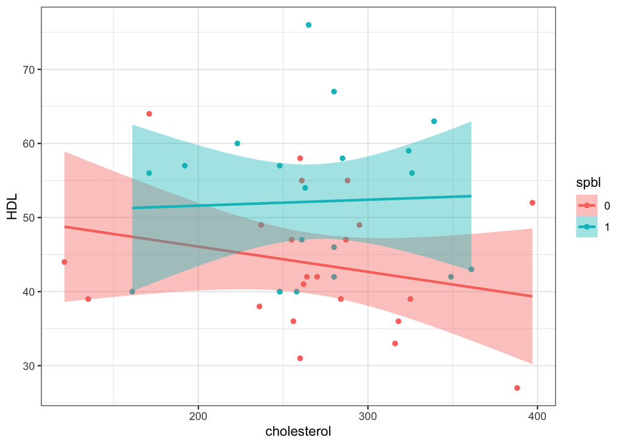

```r
 # plot
hdl$spbl <- as.factor(hdl$spbl)

hdl %>%
  ggplot(aes(x=cholesterol, y=HDL, color = spbl)) +
  geom_point() +
  geom_smooth(method = "lm", aes(fill= spbl)) +
  theme_bw() +
  labs(color = "spbl", fill = "spbl")
```

### Part 12) Testing for equality of lines

**Fitting the model I need to test for coincidence (equality) of the two lines in part 9.**

```r
# test for equality of lines
eq_line <-lm(HDL ~ cholesterol, data=hdl)

anova(eq_line,fit_spbl_yn)
```

|  | Res.Df | RSS | Df | Sum of Sq | F | Pr(>F) |
| --- | --- | --- | --- | --- | --- | --- |
| 1 | 40 | 4567.383 | NA | NA | NA | NA |
| 2 | 38 | 3768.025 | 2 | 799.3583 | 4.030707 | 0.02585117 |

Interpretation: We reject the null as p-value for the F statistics is 0.03 (<0.05). This means that at least one of the intercept or the slope is different for different levels of spbl. The lines are not the same.

### Part 13) Testing for parallel lines

**Fitting the model I need to test for parallelism (equal slopes) of the two lines in part 9.**

```r
# test for parallel lines (equal slopes)
par_line <-lm(HDL ~ cholesterol + spbl, data=hdl)

anova(par_line,fit_spbl_yn)
```

|  | Res.Df | RSS | Df | Sum of Sq | F | Pr(>F) |
| --- | --- | --- | --- | --- | --- | --- |
| 1 | 39 | 3830.450 | NA | NA | NA | NA |
| 2 | 38 | 3768.025 | 1 | 62.42474 | 0.6295447 | 0.432449 |

Interpretation: We fail to reject the null, as p-value for the F statistics is 0.4324 (>0.05). The intercept can differ based on spbl, but the slopes are the same. The lines are parallel.

### Part 14) Centering variables

**Centering the cholesterol and triglyceride variables at their mean value and refit the model from part 9.**

```r
# center values
hdl = hdl %>% mutate(chol_center = cholesterol -mean(cholesterol))

# refit models with centered values
refit <- lm(HDL ~ chol_center + spbl*chol_center, data=hdl)
summary(refit)
```

```
##
## Call:
## lm(formula = HDL ~ chol_center + spbl * chol_center, data = hdl)
##
## Residuals:
##     Min      1Q  Median      3Q     Max
## -13.030  -8.883  -1.791   6.051  23.875
##
## Coefficients:
##                   Estimate Std. Error t value Pr(>|t|)
## (Intercept)       43.76374    2.12304  20.614  < 2e-16 ***
## chol_center       -0.03405    0.03282  -1.038  0.30600
## spbl1              8.38396    3.07658   2.725  0.00966 **
## chol_center:spbl1  0.04199    0.05292   0.793  0.43245
## ---
## Signif. codes:  0 '***' 0.001 '**' 0.01 '*' 0.05 '.' 0.1 ' ' 1
##
## Residual standard error: 9.958 on 38 degrees of freedom
## Multiple R-squared:  0.1833, Adjusted R-squared:  0.1188
## F-statistic: 2.843 on 3 and 38 DF,  p-value: 0.05051
```

The intercept changes and the slopes stay the same.

Interpretation of intercept in original model: The expected HDL would be 52.9 mg/dL if cholesterol was 0.

Interpretation of intercept in new model with centered variables: The expected HDL would be 43.8 mg/dL for those with mean cholesterol levels.

### Part 15) Scaling varibales

**Converting the units of measurement for cholesterol from mg/dL to mmol/L.**

$$x \text{ mg/dL} = x \text{ mg/dL}\frac{1
\text{ mmol/L}}{38.67\text{ mg/dL}} =\frac{x}{38.67}\text{
mmol/L}$$

**Applying this transformation and comparing the simple linear regression model I fit in part 1 for cholesterol to a new model using the (uncentered) cholesterol value measured in mmol/L.**

```r
# rescale variable
hdl = hdl %>% mutate(chol_mmol = cholesterol*(1/38.67))

# refit model and compare to original model
refit2 <- lm(HDL ~ chol_mmol, data=hdl)

summary(refit2)
```

```
##
## Call:
## lm(formula = HDL ~ chol_mmol, data = hdl)
##
## Residuals:
##     Min      1Q  Median      3Q     Max
## -18.649  -8.066  -1.267   7.827  28.189
##
## Coefficients:
##             Estimate Std. Error t value Pr(>|t|)
## (Intercept)  52.4702     7.5806   6.922 2.41e-08 ***
## chol_mmol    -0.6798     1.0684  -0.636    0.528
## ---
## Signif. codes:  0 '***' 0.001 '**' 0.01 '*' 0.05 '.' 0.1 ' ' 1
##
## Residual standard error: 10.69 on 40 degrees of freedom
## Multiple R-squared:  0.01002,    Adjusted R-squared:  -0.01473
## F-statistic: 0.4049 on 1 and 40 DF,  p-value: 0.5282
```

```r
summary(slr1)
```

```
##
## Call:
## lm(formula = HDL ~ cholesterol, data = hdl)
##
## Residuals:
##     Min      1Q  Median      3Q     Max
## -18.649  -8.066  -1.267   7.827  28.189
##
## Coefficients:
##             Estimate Std. Error t value Pr(>|t|)
## (Intercept) 52.47018    7.58057   6.922 2.41e-08 ***
## cholesterol -0.01758    0.02763  -0.636    0.528
## ---
## Signif. codes:  0 '***' 0.001 '**' 0.01 '*' 0.05 '.' 0.1 ' ' 1
##
## Residual standard error: 10.69 on 40 degrees of freedom
## Multiple R-squared:  0.01002,    Adjusted R-squared:  -0.01473
## F-statistic: 0.4049 on 1 and 40 DF,  p-value: 0.5282
```

Interpretation: Only the slope gets sclaed by 38.67 (38.67 times bigger, -0.6798 = -0.01758*38.67) and the intercept doesn’t change (52.4702 remained the same).